# Technical Report MP4

```python
import seaborn as sns
import folium
import matplotlib.ticker as mtick
import sqlite3
import pandas as pd
import numpy as np
import matplotlib.pyplot as plt
import seaborn as sns
from tqdm import tqdm

from sklearn.preprocessing import StandardScaler
from sklearn.feature_extraction.text import TfidfVectorizer
from sklearn.decomposition import PCA, TruncatedSVD
from scipy.spatial.distance import euclidean, cityblock
from sklearn.base import clone
from IPython.display import HTML
import pprint
import re
from collections import Counter
from IPython.display import display_html
from wordcloud import WordCloud, STOPWORDS
from sklearn.preprocessing import StandardScaler
from sklearn.feature_extraction.text import TfidfVectorizer
from sklearn.feature_extraction import stop_words, text
from sklearn.manifold import TSNE
from sklearn.decomposition import TruncatedSVD
from scipy.spatial.distance import euclidean, cityblock
from IPython.display import HTML, display
from scipy.spatial.distance import euclidean
from sklearn.cluster import KMeans
from scipy.cluster.hierarchy import linkage, dendrogram
from sklearn.pipeline import make_pipeline
from sklearn.preprocessing import Normalizer
from nltk.tokenize import sent_tokenize, word_tokenize
from nltk.stem.porter import PorterStemmer
from nltk.stem.snowball import SnowballStemmer
from nltk.corpus import stopwords
from nltk import FreqDist, RegexpTokenizer
from PIL import Image
from operator import itemgetter

from sklearn.cluster import KMeans
from sklearn.feature_extraction.text import TfidfVectorizer
from sklearn.metrics import calinski_harabasz_score, silhouette_score
import itertools
import nltk

pd.set_option('display.max_columns', 500)


font = "Roboto-Regular.ttf"
pp = pprint.PrettyPrinter(indent=4, width=100)


HTML('''
<style>
.output_png {
    display: table-cell;
    text-align: center;
    vertical-align: middle;
}


</style>


<script>
code_show=true;
function code_toggle() {
 if (code_show){
 $('div.input').hide();
 } else {
 $('div.input').show();
 }
 code_show = !code_show
}
$( document ).ready(code_toggle);
</script>
<form action="javascript:code_toggle()"><input type="submit" value="Click here to toggle on/off the raw code."></form>
''')
```

```python
#RUN ONLY ONCE TO DOWNLOAD NLTK sets
# nltk.download('stopwords')
# nltk.download('punkt')
# nltk.download('wordnet')
```

Surprise, Arizona: Discovering Major Topics of Customer Reviews

EXECUTIVE SUMMARY

Surprise is a small, quiet city in Arizona that has attracted many elderly and new families due to relatively low-cost of living. But over the years, the city has become heavily commercialized which caused many small business owners to go out of business. Current small business owners though could still compete by looking at current trends and expanding their offerings and improving services. These opportunities can be identified by going through customer reviews from websites like Yelp. Yelp publishes crowd-sourced reviews about local businesses. In this study, we examine the customer reviews, extracted from Yelp, of local businesses in Surprise, Arizona. To identify the major topics consumers are talking about, the review corpus extracted from Yelp were cleaned, stemmed and vectorized. Before clustering using $k$-medians technique, dimensionality reduction was applied using singular value decomposition (SVD). This resulted to 6 main topics with food and services as the over-arching themes: happy hour experience, casual dining reviews, home, professional, beauty and mixed services feedbacks.

INTRODUCTION

Today’s consumers are more reliant on reviews and ratings when it comes to selecting the products to purchase and services to avail. They are also more vocal and open to share their experiences on social media and websites like Yelp. Yelp is a well-known website that publishes crowd-sourced reviews about local businesses. In [2019](https://www.yelp-ir.com), Yelp reported having a monthly average of 96 million unique visitors on both desktop and mobile. Currently, it has around 205 million reviews and ratings of different business types (e.g. restaurants and beauty parlors). Reviews are usually short text consisting of few lines with about a hundred words. The reviews left by the customers often describe various features about a business and their experience with respect to those features.

Customer reviews contribute significantly to the success of any kind of business. In commercialized cities like Surprise, Arizona, small business owners could leverage on these reviews to improve and expand their products and services. In a city known to be a safe, calm, and has a lot of families, it has attracted many retirement communities and rather conservative residents. In analyzing reviews, business owners can understand what topics customers talk about and care for, but in doing so, they would go through hundreds of reviews which corresponds to about a thousand words. In this study, we examine the businesses and reviews data of Surprise, Arizona obtained from the Yelp website. The study aims to answer the question: **What are the customers of Surprise talking about?**

BUSINESS VALUE

METHODOLOGY

1. Data Extraction
2. Data Storage
3. Data Preprocessing
4. Exploratory Data Analysis
5. Feature Extraction
6. Dimensionality Reduction
7. Unsupervised Clustering

Each step of the workflow will be discussed in the succeeding sections.

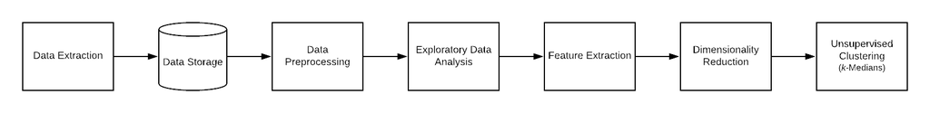

#### Figure 1. Workflow for clustering Yelp reviews

### 1. Data Extraction

The Yelp dataset contains businesses, reviews, and user data available for personal, educational, and academic use. This was extracted from the Yelp website and stored in Jojie as JSON files. The exact methodology for the data extraction of data from Yelp is unknown to the researchers.

For this study, only the businesses and reviews for Surprise, Arizona were considered. First, all unique business IDs that are located in Surprise City were queried from */mnt/data/public/yelp/challenge12/yelp_dataset/yelp_academic_dataset_business.json* in Jojie. From these, reviews of all these businesses were pulled from this file: */mnt/data/public/yelp/challenge12/yelp_dataset/yelp_academic_dataset_review.json*.

```python
def get_reviews(business_id):
    """
    Return pandas DataFrame with keys as columns and 'business_id' as index.

    Return
    ------
    dframe : pandas.DataFrame
        A pandas DataFrame with keys and dot-separated nested keys as columns
        'business_id' as index.
    """

    path = ('/mnt/data/public/yelp/challenge12/yelp_dataset/'
            'yelp_academic_dataset_review.json')
    with open(path) as f:
        head = [json.loads(next(f)) for x in range(188593)]
        reviews = pd.json_normalize(head)
    return reviews[reviews['business_id'].isin(business_id)]
def get_business(city):
    """
    Return pandas DataFrame with keys as columns and 'business_id' as index.

    Return
    ------
    dframe : pandas.DataFrame
        A pandas DataFrame with keys and dot-separated nested keys as columns
        'business_id' as index.
    """

    path = ('/mnt/data/public/yelp/challenge12/yelp_dataset/'
            'yelp_academic_dataset_business.json')
    with open(path) as f:
        head = [json.loads(next(f)) for x in range(188593)]
        df = pd.json_normalize(head)
    return df[df['city'].isin(city)]
# ------------------------------------------------------------------------
city = ['Surprise','Suprise','Surprise Crossing']
business = get_business(city)
# get review for all businesses in Surprise, AZ
reviews = get_reviews(list(business['business_id']))
```

```python
conn1 = sqlite3.connect('surprise.db',timeout=10)
business.to_sql('business',conn1,if_exists='replace', index=False)
reviews.to_sql('reviews',conn1,if_exists='replace', index=False)
```

### 2. Data Storage

```python
file = 'surprise.db'
conn = sqlite3.connect(file)
df_reviews = pd.read_sql("SELECT * from reviews", conn)
df_business = pd.read_sql('''SELECT business_id, name, stars, categories,
                          address, latitude, longitude from business''', conn)
```

The extracted reviews were stored in a local `sqlite` database, `surprise.db`. A total of **1,076** text reviews were stored in the `reviews` table. Table 1 shows the data description while Table 2 displays the sample data.

#### Table 1. Reviews Data description

| Data | Description |
| --- | --- |
| **review_id** | unique ID of the review |
| **business_id** | unique ID of the establishment the review is written for |
| **user_id** | unique ID of user that wrote the review |
| **text** | text review of the establishment |
| **star** | start rating of the establishment |
| **useful** | number of useful votes received |
| **funny** | number of funny votes received |
| **cool** | number of cool votes received |

#### Table 2. Sample raw reviews in the Yelp database

```python
df_reviews.head(2)
```

|  | review_id | user_id | business_id | stars | date | text | useful | funny | cool |
| --- | --- | --- | --- | --- | --- | --- | --- | --- | --- |
| 0 | ULkRg1RFnmkTPIsiiRIyuA | q3AiAe-AcpDrNsdZf8nCvQ | xIrFmRqK4TpwvaxlU926TQ | 4 | 2013-06-24 | pretty awesome place. A lot to do and it's go... | 1 | 0 | 1 |
| 1 | xQtIDd-lijxV4rhyE-ekjg | q3AiAe-AcpDrNsdZf8nCvQ | YcyWmqda0JJ5BNTqtBsb5g | 5 | 2012-08-18 | Mike came out and fixed our AC again! A whole... | 4 | 2 | 3 |

The extracted business information was stored in the same database. A total of **1,121** rows were stored in the `business` table. Table 3 shows the data description.

#### Table 3. Business Data description

| Data | Description |
| --- | --- |
| **business_id** | unique ID of the business |
| **name** | business name |
| **stars** | star rating of the business, rounded to half-stars |
| **categories** | business categories of the establishment |
| **address** | business address of the establishment |
| **latitude** | latitude value of the business' location |
| **longitude** | latitude value of the business' location |

#### Table 4. Sample business data in the Yelp database

```python
df_business.head(2)
```

|  | business_id | name | stars | categories | address | latitude | longitude |
| --- | --- | --- | --- | --- | --- | --- | --- |
| 0 | tXMYTZc0lxLNpnU1lI5j0Q | Walgreens | 4.0 | Shopping, Drugstores, Medical Supplies | 13723 N Litchfield Rd | 33.609060 | -112.359005 |
| 1 | FNEfDBCvCcsKvw6JeQawAw | West Valley Motor Vehicle Title Express | 4.5 | Public Services & Government, Departments of M... | 12801 W Bell Rd, Ste 113 | 33.637146 | -112.337027 |

### 3. Data Pre-processing

```python
df_business.categories = df_business.categories.str.split(",", n=1,expand=True)[0]
```

Most businesses have multiple categories. For this study, we will only retain the most relevant category of the business which is the first category on the list. The main information we will work with are the customer reviews. Before clustering the reviews text the following transformations were made:

1. Convert all characters into lowercase.
2. Remove Stopwords
3. Stemming and Lemmatization
4. Tokenization

### 4. Exploratory Data Analysis

```python
df = pd.merge(df_business[['name', 'business_id',
                           'stars','latitude', 'longitude']],
              df_reviews.groupby('business_id')[['useful','funny','cool']]
                        .mean()
                        .reset_index(),
              left_on='business_id', right_on='business_id',
              how='left')

df['tag'] = df['cool'].apply(lambda x: 'No Reviews'
                             if  np.isnan(x) else 'With Reviews')
```

Prior to performing unsupervised clustering, exploratory data analysis was performed to understand the data and see if some obvious topics stand out in the review corpus.

As shown in Figure 2, only about $40\%$ of businesses registered in Yelp have reviews in form of text. This can be attributed to how businesses fail to translate customer experience to customer engagement. Although the 90-9-1 rule for participation inequality in social media and online communities is a wide accepted [research](https://www.nngroup.com/articles/participation-inequality/), businesses should exert effort to motivate their customers into providing reviews which can help them improve their [products and services](https://www.womply.com/blog/why-most-customers-dont-leave-reviews-and-what-you-should-do-about-it/).

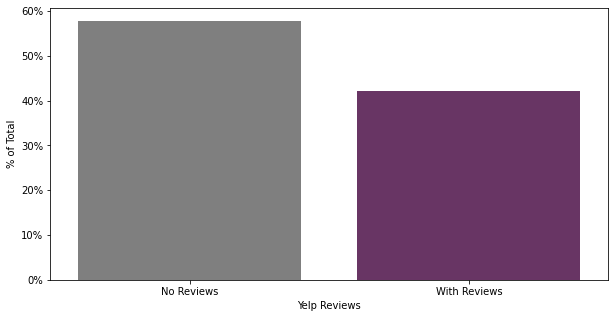

```python
viz = (df.groupby('tag')[['tag']]
         .agg('count')
         .rename(columns={'tag':'count'})
         .reset_index())

viz['total'] = df.shape[0]
viz['percent'] = viz['count']/viz['total'] * 100


fig, ax = plt.subplots(figsize=(10,5))
g = sns.barplot(x='tag',
                y='percent',
                data=viz,
                palette = ['#7F7F7F', '#712C6B']);

ax.set_ylabel('% of Total')
ax.set_xlabel('Yelp Reviews')
ax.yaxis.set_major_formatter(mtick.PercentFormatter())
# g.legend_.remove()
plt.show();
```

```python
def stars(x):
    if x == 5:
        return "⭐⭐⭐⭐⭐"
    elif x >= 4:
        return "⭐⭐⭐⭐"
    elif x >= 3:
        return "⭐⭐⭐"
    elif x >= 2:
        return "⭐⭐"
    elif x >= 1:
        return "⭐"


def plot_eda(reviews):
    reviews = reviews.str.lower()
    eng_contractions = ['the', 'we']
    stopwords_eng = set(stopwords.words('english') + eng_contractions)

    tokenizer = RegexpTokenizer(r'\w{2,}')
    word_tokens = tokenizer.tokenize(' '.join(reviews))
    reviews_filtered = [w for w in word_tokens if not w in stopwords_eng]
    counts = FreqDist(reviews_filtered)
    labels, values = zip(*counts.items())
    indSort = np.argsort(values)[::]
    labels = np.array(labels)[indSort[-20:]]
    values = np.array(values)[indSort[-20:]]
    indexes = np.arange(len(labels))

    bar_width = 0.35
    fig, ax = plt.subplots(1, 2, dpi=100, figsize=(11, 4))

    ax[1].barh(indexes, values, color='#712c6b')
    ax[1].set_xlabel('Word count')
    ax[1].set_title('Most common words in reviews')
    ax[1].set_yticks(indexes + bar_width)
    ax[1].set_yticklabels(labels)


    wordcloud = (WordCloud(background_color='white', max_words=5000,
                      min_font_size=8,
                      stopwords=stopwords_eng.union(text.ENGLISH_STOP_WORDS),
                      width=500, height=375,
                      prefer_horizontal=0.75, relative_scaling=.5)
                     .generate(' '.join(reviews_filtered)))

    ax[0].imshow(wordcloud, interpolation='bilinear')
    ax[0].axis('off')
```

```python
lat = 33.630554
lon = -112.366669

df['star_rating'] = df['stars'].apply(lambda x: stars(x))
main = folium.Map(location=[lat, lon],
                  zoom_start=13)

list_groups = ['⭐⭐⭐⭐⭐', '⭐⭐⭐⭐', '⭐⭐⭐',
               '⭐⭐', '⭐']

for rating in list_groups:
    feature_group = folium.FeatureGroup(rating)
    df_5_2 = df[df['tag']=='With Reviews'].copy()
    df_5_2 = df_5_2[df_5_2['star_rating'] == rating]
    for row in df_5_2.itertuples():
        popup_str = f"""<b>{row.name}</b>  <br> Rating: {row.stars}"""
        popup = folium.Tooltip(popup_str)
        folium.Circle(location=[row.latitude, row.longitude],
                      fill = True,
                      fill_opacity = 0.8,
                      color = '#712C6B',
                      radius=50,
                      tooltip=popup).add_to(feature_group)
    feature_group.add_to(main)


folium.LayerControl(collapsed=False).add_to(main)
main
```

[interactive chart not shown]

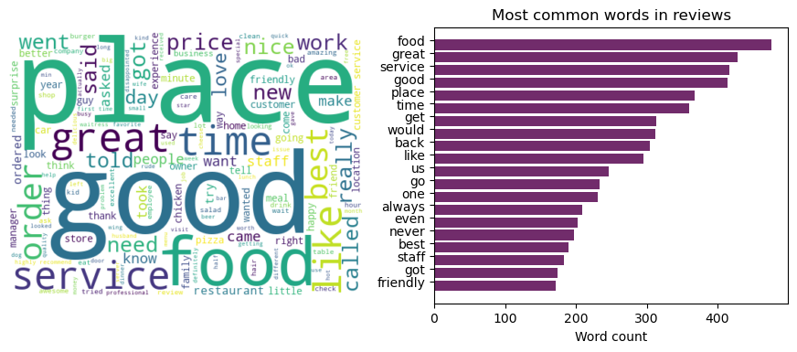

```python
plot_eda(df_reviews['text'])
```

### 5. Feature Extraction

Features were extracted from the review corpus using word stemming and term frequency-inverse document frequency (TF-IDF) vectorizer via Python’s modules `nltk` PorterStemmer and `scikit-learn`’s TF-IDF vectorizer, respectively.

Table 5 shows the additional parameters considered in the TF-IDF vectorizer.

After vectorization, the collection of reviews has 1, 1156 items in its vocabulary.

#### Table 5. Hyperparameters used in TF-IDF vectorizer

| Parameter | Description | Value |
| --- | --- | --- |
| `token_pattern` |  | [a-z\’-] |
| `stop_words` | english |  |
| `max_df` | 95 |  |
| `min_df` | 5 |  |

```python
def do_nltk(docs):
    """Return documents implemented with NLTK."""
    corpus = []

    for i in range(len(docs)):
        review = re.sub('[^a-zA-Z]', ' ', docs[i])
        review = review.lower()
        review = review.split()

        # take main stem of each word
        ps = PorterStemmer()

        # loop for stemming each word
        review = [ps.stem(word) for word in review
                    if not word in set(stopwords.words('english'))]

        review = ' '.join(review)
        corpus.append(review)

    return corpus

def tfidf_design_matrix(corpus):
    """Return pandas DataFrame of TF-IDF vectorized corpus."""

    tfidf_vectorizer = TfidfVectorizer(token_pattern=r'[a-z\'-]+',
                                   stop_words='english',max_df=95,
                                   min_df=5)

    bow_rev = tfidf_vectorizer.fit_transform(corpus)

    # Words in the documents
    vocabulary = tfidf_vectorizer.get_feature_names()

    return pd.DataFrame(bow_rev.todense(), columns=vocabulary)


corpus = do_nltk(df_reviews['text'].str.lower())
df_rev = tfidf_design_matrix(corpus)
```

### 6. Dimensionality Reduction

After performing TF-IDF vectorization on the reviews, the design matrix of the reviews had **1076** rows represented by the individual reviews, and **1156** columns represented by the unique words used in the reviews. To improve the run-time in clustering the reviews, the concept of **singular value decomposition (SVD)** was applied on the design matrix. Then, the variance explained by the singular values was plotted as shown in Figure 5.

```python
def truncated_svd(X):
    """Returns q, sigma, p and the normalized sum of squared distance from
    the origin.
    """
    q, s, p = np.linalg.svd(X)
    return q, np.diag(s), p.T, ((s**2) / np.sum(s**2))


def project_svd(q, sigma, k):
    """Return the design matrix projected on to the first k singular
    vectors.
    """
    return q[:, :k].dot(sigma[:k, :k])

def plot_nssd(nssd):
    fig, ax = plt.subplots(figsize=(8,5))
    ax.plot(range(1, len(nssd)+1), nssd, 'o-', label='individual',
                        color='orange')
    ax.plot(range(1, len(nssd)+1), nssd.cumsum(),
                        'o-', label='cumulative', color='#712c6b')
    ax.legend()
    ax.set_ylim(0, 1)
    ax.set_xlabel('SV')
    ax.set_ylabel('variance explained')
    ax;

def plot_svd(X_new, features, p):
    """
    Plot transformed data and features on to the first two singular vectors

    Parameters
    ----------
    X_new : array
        Transformed data
    featurs : sequence of str
        Feature names
    p : array
        P matrix
    """
    fig, ax = plt.subplots(1, 2, figsize=(20,8))
    ax[0].scatter(X_new[:,0], X_new[:,1])
    ax[0].set_xlabel('SV1')
    ax[0].set_ylabel('SV2')

    for feature, vec in zip(features, p):
        ax[1].arrow(0, 0, 1 * vec[0], 1 * vec[1], width=0.01,
                    ec='none', fc='r')
        ax[1].text(1 * vec[0], 1 * vec[1], feature, ha='center',
                   color='r', fontsize=10)
    ax[1].set_xlim(-1.5, 1.5)
    ax[1].set_ylim(-1, 1)
    ax[1].set_xlabel('SV1')
    ax[1].set_ylabel('SV2')


def plot_sv_bars(df, p):
    feature_names = df.columns
    for i in range(20):
        fig, ax = plt.subplots(figsize=(10,5))
        order = np.argsort(np.abs(p[:, i]))[-20:]
        ax.barh([feature_names[o] for o in order], p[order, i])
        ax.set_title(f'SV{i+1}')
        ax;
```

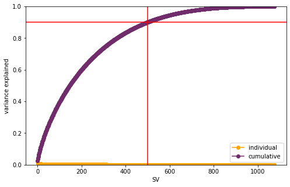

```python
q, sigma, p, nssd = truncated_svd(df_rev)


plot_nssd(nssd)
plt.axhline(0.9, color='red')
plt.axvline(500, color='red');
```

#### Figure 5. Variance explained by singular values

```python
rev_new = project_svd(q, sigma, 500)
```

Based on the plot of the singular values with the corresponding variance explained, the 500 singular values with the highest amount of variance explained retain 90% of the overall variance of the data. Hence, we used these 500 singular values to be the columns of the new design matrix, and thus producing a 1076 by 500 matrix. This truncated matrix will be used in the clustering of reviews.

### 7. Unsupervised Learning

In clustering the reviews, **$k$-medians** clustering was used to make the algorithm insensitive to outliers. Note that in dealing with “related” reviews, a word may appear in a document multiple times and only once in another document. However, it does not mean that these documents should not be in the same cluster. If we use mean in this case, there is a chance that the two documents will be determined by different centroids. Hence, we decided to do $k$-medians clustering in this study.

```python
def plot_clusters(X, ys):
    """Plot clusters given the design matrix and cluster labels"""
    k_max = len(ys) + 1
    k_mid = k_max//2 + 2
    fig, ax = plt.subplots(2, k_max//2, dpi=150, sharex=True, sharey=True,
                           figsize=(10,5))#, subplot_kw=dict(aspect='equal'),
                           #gridspec_kw=dict(wspace=0.01))
    for k,y in zip(range(2, k_max+1), ys):
        if k < k_mid:
            ax[0][k%k_mid-2].scatter(*zip(*X), c=y, s=5, alpha=0.8)
            ax[0][k%k_mid-2].set_title('$k=%d$'%k)
            # ax[0][k%k_mid-2].set_ylim(-0.1, 0.35)
        else:
            ax[1][k%k_mid].scatter(*zip(*X), c=y, s=5, alpha=0.8)
            ax[1][k%k_mid].set_title('$k=%d$'%k)
            # ax[1][k%k_mid-2].set_ylim(-0.1, 0.35)
    return ax


def plot_internal(inertias, chs, scs, gss, gssds):
    """Plot internal validation values."""

    fig, ax = plt.subplots(4,1,dpi=100, figsize=(8,12))
    plt.subplots_adjust(hspace=.3)
    ks = np.arange(2, len(inertias)+2)
    ax[0].plot(ks, inertias, '-o', label='SSE', c='#712c6b')
    ax[1].plot(ks, chs, '-o', label='CH', c='#712c6b')
    ax[0].set_xlabel('$k$')
    ax[1].set_xlabel('$k$')
    ax[2].plot(ks, gss, '-o', label='Gap statistic', color = '#712c6b')
    ax[3].plot(ks, scs, '-o', label='Silhouette coefficient', c='#712c6b')
    ax[2].set_xlabel('$k$')
    ax[3].set_xlabel('$k$')
    ax[0].legend()
    ax[1].legend()
    ax[2].legend()
    ax[3].legend()
    return ax


def pooled_within_ssd(X, y, centroids, dist):
    """Compute pooled within-cluster sum of squares around the cluster mean

    Parameters
    ----------
    X : array
        Design matrix with each row corresponding to a point
    y : array
        Class label of each point
    centroids : array
        Number of pairs to sample
    dist : callable
        Distance between two points. It should accept two arrays, each
        corresponding to the coordinates of each point

    Returns
    -------
    float
        Pooled within-cluster sum of squares around the cluster mean
    """

    ssd = np.zeros(len(centroids))
    for i, pt in zip(y, X):
        ssd[i] += dist(pt, centroids[i])**2
    return np.sum(ssd / np.array([2 * y.tolist().count(i)
                                  for i in set(y)]))


def cluster_range_kmedians(X, k_start, k_stop, actual=None):
    ys = []
    inertias = []
    chs = []
    scs = []
    gss = []
    gssds = []
    ps = []
    amis = []
    ars = []
    for k in tqdm(range(k_start, k_stop+1)):
        clusterer_k = kmedians(X, X[:k,:], ccore=False)
        # YOUR CODE HERE
        clusterer_k = clusterer_k.process()
        y = clusterer_k.predict(X)
        ys.append(y)

        # Inertia computation
        centroids = clusterer_k.get_medians()

        #inertias.append(pooled_within_ssd(X, y, centroids, cityblock))
        inertia = 0
        for c_index in clusterer_k.get_clusters():
            if len(c_index) == 1:
                continue
            for pt in X[c_index[1:]]:
                inertia += cityblock(X[c_index[0]], pt)**2
        inertias.append(inertia)

        chs.append(calinski_harabasz_score(X, y))
        scs.append(silhouette_score(X, y))
        if actual is not None:
            ps.append(purity(actual, y))
            amis.append(adjusted_mutual_info_score(actual, y))
            ars.append(adjusted_rand_score(actual, y))
        centers = np.array(clusterer_k.get_medians())

        gs = gap_statistic_kmedians(X, y, clusterer_k.get_medians(), 5)
        gss.append(gs[0])
        gssds.append(gs[1])
    # YOUR CODE HERE
    return_dict = {'ys' : ys, 'inertias' : inertias, 'chs' : chs,
                   'gss' : gss, 'gssds' : gssds, 'scs' : scs}

    if actual is not None:
        return_dict['ps'] = ps
        return_dict['amis'] = amis
        return_dict['ars'] = ars

    return return_dict

def gap_statistic_kmedians(X, y, centroids, b):
    """Compute the gap statistic for a k-medians clusterer

    Parameters
    ----------
    X : array
        Design matrix with each row corresponding to a point
    y : array
        Class label of each point
    centroids : array
        Number of pairs to sample
    b : int
        Number of realizations for the reference distribution

    Returns
    -------
    gs : float
        Gap statistic
    gs_std : float
        Standard deviation of gap statistic
    """
    np.random.seed(1337)

    minimum = X.min(0)
    maximum = X.max(0)

    log_wk = []
    for i in range(b):
        # drawing from a uniform distribution
        X_ = np.random.uniform(minimum, maximum, size=X.shape)
        kmed = kmedians(X_, X_[:len(centroids),:], ccore=False)
        kmed = kmed.process()
        # fitting the drawn values
        y_ = kmed.predict(X_)

        log_wk.append(np.log(pooled_within_ssd(X_, y_,
                                               np.array(kmed.get_medians()),
                                               cityblock)))

    return [np.mean(log_wk - np.log(pooled_within_ssd(X, y, centroids,
                                                      cityblock))),
            np.std(log_wk - np.log(pooled_within_ssd(X, y, centroids,
                                                     cityblock)))]
```

After performing $k$-medians clustering with number of clusters $k=2$ to $k=7$, and plotting the two singular values with the highest variance explained under SVD in a two-dimensional plane, the graphs in Figure 6 were shown to have an initial look at the possible clustering.

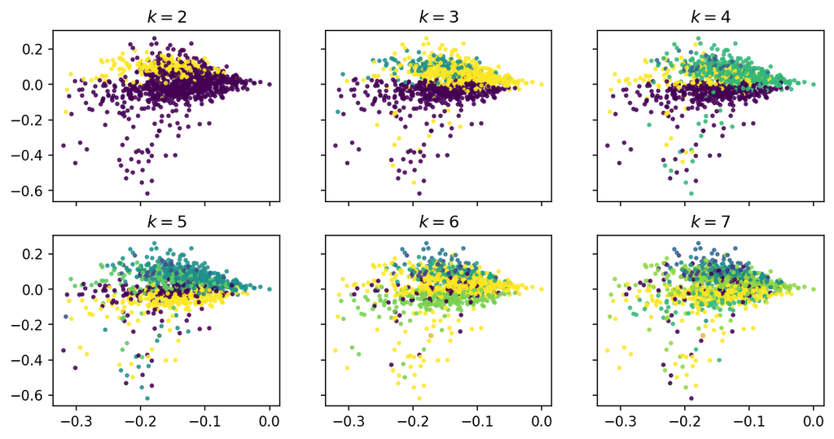

```python
from pyclustering.cluster.kmedians import kmedians

# k-medians clustering; k from 2 to 7
kmed_rev = cluster_range_kmedians(np.array(rev_new), 2, 7)
plot_clusters(np.array(rev_new)[:,:2], kmed_rev['ys']);
```

#### Figure 6. Two-SV (SVD) representation of $k$ clusters

However, it is worth noting that the top two singular values do not really explain much the overall variance of the dataset. Thus, a quantitative measure is necessary to determine the number of clusters that produces ‘good’ clustering. For this, internal validation was performed for each of the number of clusters tested. Specifically, the internal validation criteria used were **(1) sum of squared distances to the centroids, (2) Calinski-Harabasz index, (3) Silhouette index coefficient, and (4) Gap statistic.**

The results of the internal validation are shown in Figure 7.

In choosing the appropriate number of clusters, we considered a balance between the results of the internal validation and interpretability of the clusters formed. Looking at the internal validation results, the gap statistic and inertia favor $k=6$ while Calinski-Harabasz index and Silhouette coefficient favor $k=3$ and $k=7$, respectively. Hence, we chose $k=6$ to be the number of clusters.

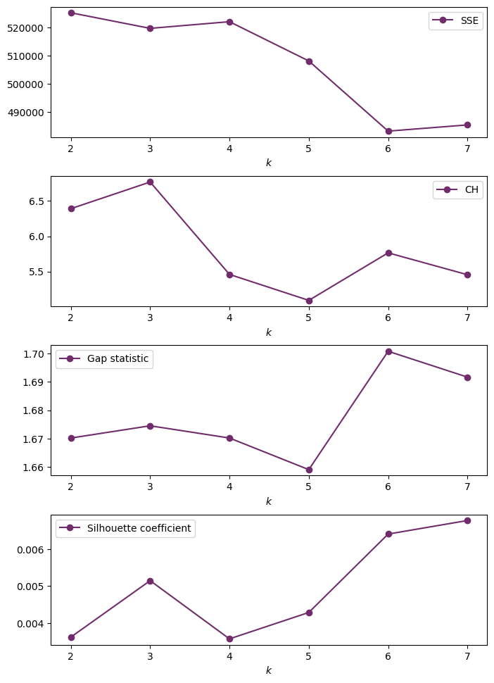

```python
# internal validation
plot_internal(kmed_rev['inertias'], kmed_rev['chs'], kmed_rev['scs'],
              kmed_rev['gss'], kmed_rev['gssds']);
```

#### Figure 7. Internal Validation Criteria for $k$ clusters

```python
def set_n_cluster(df, trunc_df, clust_num=2):
    """Return original data with cluster labels."""

    kmd = kmedians(trunc_df, trunc_df[:clust_num, :], ccore=False)
    kmd.process()
    clusters = kmd.get_clusters()
    y_predict_kmed1 = np.zeros(len(trunc_df))
    for cluster, point in enumerate(clusters):
        y_predict_kmed1[point] = cluster

    # Add cluster label to original DataFrame
    df['label'] = y_predict_kmed1

    return df
```

```python
rev_label = set_n_cluster(df_reviews, rev_new, clust_num=6)
rev_label.label = rev_label.label.apply(lambda x : int(x + 1))
```

RESULTS AND INSIGHTS

The results of the unsupervised clustering showed that there are $6$ major topics the customers in Surprise talk about and care for. We found out that among the six clusters formed, two clusters mainly talk about food (clusters 1 and 5) while the other four clusters are dominantly focused on service-type businesses.

The distribution of the reviews count relative to the clusters are shown in Figure 8.

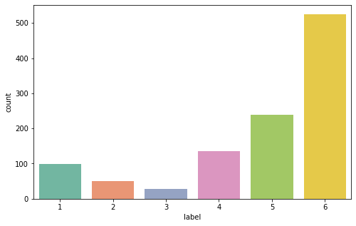

```python
plt.subplots(figsize=(8,5))
sns.countplot(x='label', data=rev_label, palette = 'Set2');
```

#### Figure 8. Count of reviews per cluster

```python
def plot_word(rev_label , x):
    """
    Display 2-gram wordcloud.

    PARAMETERS:
    rev_label : DataFrame
        DataFrame with the reviews.
    x : int
        Label of reviews
    """

    WNL = nltk.WordNetLemmatizer()
    rawText = (rev_label[rev_label.label == x].clean.str.cat())
    rawText = rawText.lower()

    # Remove single quote early since it causes problems with the tokenizer.
    rawText = rawText.replace("'", "")
    tokens = nltk.word_tokenize(rawText)
    text = nltk.Text(tokens)

    # Load default stop words and add a few more.
    stopWords = stopwords.words('english')

    # Remove extra chars and remove stop words.
    text_content = [''.join(re.split("[ .,;:!?‘’``''@#$%^_&*()<>{}~\n\t\\\-]",
                                     word)) for word in text]
    text_content = [word for word in text_content if word not in stopWords]

    # Remove any entries where the len is zero.
    text_content = [s for s in text_content if len(s) != 0]

    # Lemmatization or stemming
    text_content = [WNL.lemmatize(t) for t in text_content]

    # # setup and score the bigrams using the raw frequency.
    # finder = BigramCollocationFinder.from_words(text_content)
    # bigram_measures = BigramAssocMeasures()
    # scored = finder.score_ngrams(bigram_measures.raw_freq)

    word_fd = nltk.FreqDist(text_content)
    bigram_fd = nltk.FreqDist(nltk.bigrams(text_content))
    scored = bigram_fd.most_common()

    scoredList = sorted(scored, key=itemgetter(1), reverse=True)
    word_dict = {}
    listLen = len(scoredList)

    # Get the bigram and make a contiguous string for the dictionary key.
    # Set the key to the scored value.
    for i in range(listLen):
        word_dict[' '.join(scoredList[i][0])] = scoredList[i][1]

    out = dict(itertools.islice(word_dict.items(), 10))
    indexes= list(out.keys())
    values = list(out.values())
    fig, ax = plt.subplots(1, 2, dpi=100, figsize=(17,5))
    sns.barplot(list(out.values()), list(out.keys()), palette=['#712c6b'],ax=ax[1])

    # ax[1].barh(indexes, values, color='#e76229')
    ax[1].set_xlabel('Word count')
    ax[1].set_title("Top bi-gram word sequences in Cluster {}".format(x))
    # ax[1].set_yticks(indexes + bar_width);
    # ax[1].set_yticklabels(labels);

    wordcloud = WordCloud(background_color='white', max_words=5000, min_font_size=8,
    #                   stopwords = stopwords_eng.union(text.ENGLISH_STOP_WORDS),
                      width=500, height=375,
                      prefer_horizontal=0.75, relative_scaling=.5).generate_from_frequencies(word_dict)
    ax[0].imshow(wordcloud, interpolation='bilinear')
    ax[0].axis('off');
```

#### Let’s dig deeper into each cluster.

#### FOOD CLUSTERS (Clusters 1 and 5)

The food market in Surprise that rake in reviews can be classified into two: the “happy hour” food places (cluster 1), and fast casual and casual dining restaurants (cluster 5).

### Cluster 1: “Happy hour” food places

Looking at the most common bi-grams for this cluster as displayed in Figure 9, it can be observed that they mainly talk about food places which also cater other fun activities that are good for groups of customers. It would also seem like residents of Surprise talk a lot about their recreational activities like bowling, laser tag and night outs. People feel pretty good and easily give out 5 stars because of the excellent customer service and good food these entertainment businesses offers.

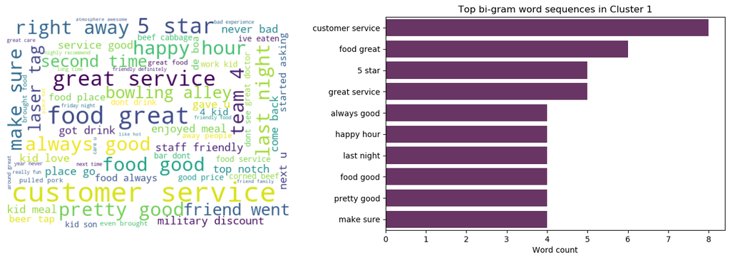

```python
plot_word(rev_label , 1)
```

#### Figure 9. Happy hour food places reviews

### Cluster 5: Fast food and casual dining restaurants

The wordcloud in Figure 10 mainly shows the types of cuisine and food that are commonly served in fast casual and casual dining restaurants. Chinese food like fried rice and orange chicken stands out. Most of the reviews are about the taste and quality of specific food offered in these restaurants.

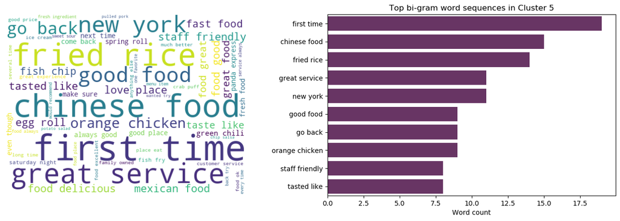

```python
plot_word(rev_label , 5)
```

#### Figure 10. Fast casual and casual dining restaurant reviews

#### CUSTOMER SERVICE CLUSTERS (Clusters 2, 3, 4 and 6)

The topics on these clusters show the different services being talked about by customers in Surprise. The topics are about home services (cluster 2), hair and beauty services (cluster 3), professional services (cluster 4) and a mix of customer services (cluster 6).

### Cluster 2: Home services

The topic that emerged in this cluster is home repair services. It is worth noting that **Cooler Tymes** surfaced as the most frequent mentioned word (depicted in the bar graph at Figure 11). This speaks a lot about the company and how it delivers services to its customers. We can also see how customers use the reviews platform to recommend businesses with which they had a good experience with.

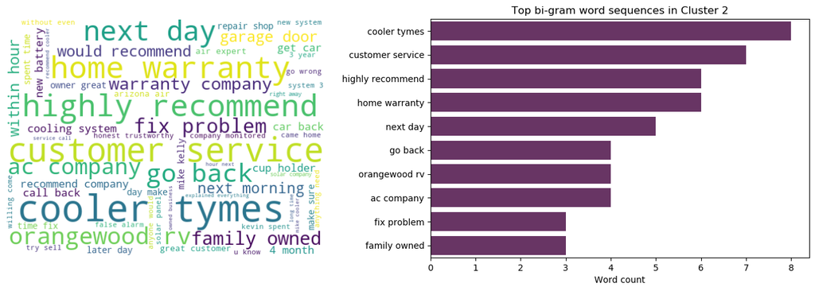

```python
plot_word(rev_label , 2)
```

#### Figure 11. Home service businesses reviews

### Cluster 3: Hair and beauty care services

Residents of Surprise also talks about and share their experiences on hair and beauty care services they avail (Figure 12). This shows how the market in Surprise value the way they look, especially their hair style.

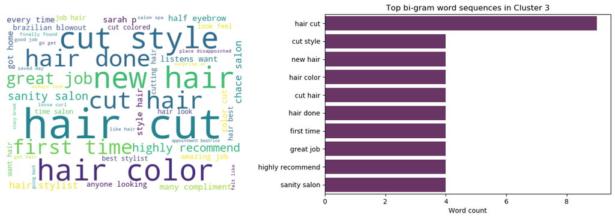

```python
plot_word(rev_label , 3)
```

#### Figure 12. Hair and beauty reviews

### Cluster 4: Professional services

Aside from the fact that this cluster is mostly composed of reviews for businesses provided professional services in Surprise, it also shows the dominant positive sentiment in this cluster given that the reviews are about recommendations of the services. Highly recommend and customer service are the top 2 most frequent phrases in this cluster, shown in Figure 13.

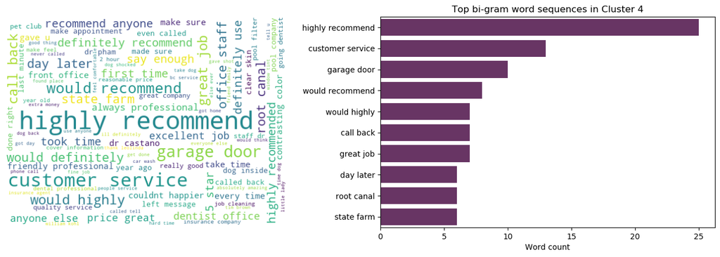

```python
plot_word(rev_label , 4)
```

#### Figure 13. Professional services reviews

## Cluster 6: Mix of customer service businesses

This cluster is a mix of reviews from both food and customer service businesses (see Figure 14). Surprisingly, businesses in this cluster are the ones that need the most improvement because nearly half of the reviews in this cluster were rated 3-stars or less. This can be seen in the next section.

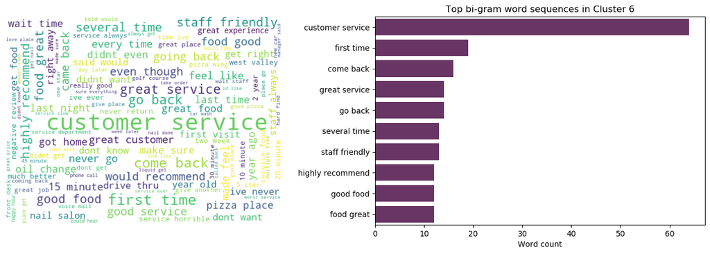

```python
plot_word(rev_label , 6)
```

#### Figure 14. Customer service in general reviews

## CUSTOMER SATISFACTION

Knowing the level of satisfaction and sentiments of customers towards products and services is a crucial information for any business. This will allow businesses to identify aspects of the business that need improvement, and the good aspects that can be further enhanced to entice more customers. Figure 15 shows how customers within each cluster are satisfied through the number of “stars” they give.

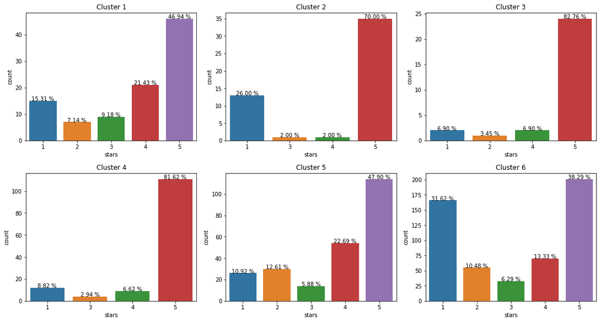

```python
df = rev_label.copy()
df['label1'] = df.label.replace({1:"Happy Food Places", 2:"Home Services",
                 3: "Beauty Services", 4: "Professional Services",
                  5:"Casual Dining Restaurants", 6: "Customer Service"})
fig, ax = plt.subplots(2,3, figsize=(15,8), constrained_layout=True)
for i in df.label.unique():
    total = float(len(df[df.label==i]))
    axis = sns.countplot(df[df.label==i].stars,
                         ax=ax[int((i - 1) // 3), int((i - 1) % 3)])
    ax[int((i - 1) // 3), int((i - 1) % 3)].set_title("Cluster "
                                                      + str(int(i)))

    for p in axis.patches:
        height = p.get_height()
        axis.text((p.get_x()) + (p.get_width() / 2),
                height,
                '{:1.2f} %'.format((height/total) * 100),
                ha="center")
```

#### Figure 15. Distribution of customer satisfaction per cluster

Based on Figure15, clusters 1, 2 and 6 need the most attention in improving the satisfaction of its customers.

CONCLUSION AND RECOMMENDATIONS

REFERENCES

[1] Yelp Investor Presentation February 2020. https://www.yelp-ir.com, retrieved August 27, 2020

[2] Anderson, B.J., Gross, D. S., Musicant, D. R., Ritz, A. M., Smith, T. G., and Steinberg, L. E. (2006) Adapting k-medians to generate normalized cluster centers. Proceedings of the Sixth SIAM International Conference on Data Mining, Society for Industrial and Applied Mathematics, pp. 165–175, Bethesda, MD.

[3] Aggarwal, C. (2015). Data Mining: The Textbook. Springer.